# Machine_Learning_Longform

Eleanor Colligan

3/7/2022

## Table of Contents:

### Introduction

### Exploratory Data Analysis

### K-Nearest-Neighbor

### Logistic Regression

### Boosted Trees

### Random Forest

### Final Model

### Conclusion

## Introduction

As a woman, I find woman’s health very interesting. Furthermore, due to the fact we live in a historically (and currently) man-focused world, there is a huge gap in women’s health research and medicine compared to men’s health. One example of this is birth control, and how reliable forms of birth control rest on women to take and deal with troubling (and) at times very serious) side effects. Furthermore, cancer is an illness that virtually touches everyone; it seems that everyone I know has a family member or friend that has been diagnosed with cancer. Breast cancer, and this data set as a result, which is at the intersection of woman’s health and cancer, combines both pressing issues. The data set I chose is from the UCI Machine Learning Respository, and can be found at: https://archive.ics.uci.edu/ml/datasets/Breast+Cancer+Wisconsin+%28Diagnostic%29. During class, I feel like we did a lot more practice with regression than with classification, or perhaps classification is just less intuitive to me given I’ve learned about regression in other statistics classes. Either way, I wanted to do my project on classification so I could understand it better. I tried four algorithms: K-Nearest-Neighbor, Logistic Regression, Random Forest, and Boosted Tree.

#### Research Question

How accurately can I predict the diagnosis (Malignant or Benign) of a tumor based off of various measurements of that tumor?

```r
library(tidyverse)
library(tibble)
library(dials)
library(skimr)
library(workflows)
library(dplyr)
library(tidytext)
library(rsample)
library(recipes)
library(naniar)
library(parsnip)
library(tune)
#set seed
set.seed(384209)
```

#### Data Set

Loading dataset into R

```r
data <- read_csv('unprocessed/data.csv') %>%
  mutate(diagnosis = factor(diagnosis, levels = c("M", "B")))
```

data check- making sure there’s no missing variables.

```r
data %>%
naniar::miss_var_summary()
```

```
## # A tibble: 33 × 3
##    variable         n_miss pct_miss
##    <chr>             <int>    <dbl>
##  1 ...33               568      100
##  2 id                    0        0
##  3 diagnosis             0        0
##  4 radius_mean           0        0
##  5 texture_mean          0        0
##  6 perimeter_mean        0        0
##  7 area_mean             0        0
##  8 smoothness_mean       0        0
##  9 compactness_mean      0        0
## 10 concavity_mean        0        0
## # … with 23 more rows
```

Removing all the variables I don’t plan on using from data_set (all variables unrelated to the mean of various measurements)

```r
data<- data %>%
select(ends_with('mean') | 'diagnosis' | 'id')
```

leaning variables names:

```r
data<- data %>%
janitor::clean_names()
```

Looking at the outcome variable:

```r
data %>%
select(diagnosis)
```

```
## # A tibble: 568 × 1
##    diagnosis
##    <fct>
##  1 M
##  2 M
##  3 M
##  4 M
##  5 M
##  6 M
##  7 M
##  8 M
##  9 M
## 10 M
## # … with 558 more rows
```

Everything looks good to me with the diagnosis variable. The options are either B (for benign) or M (malignant). There are no missing rows of data.

## Exploratory Data Analysis

looking at the distribution of the outcome variable (diagnosis) with a graph:

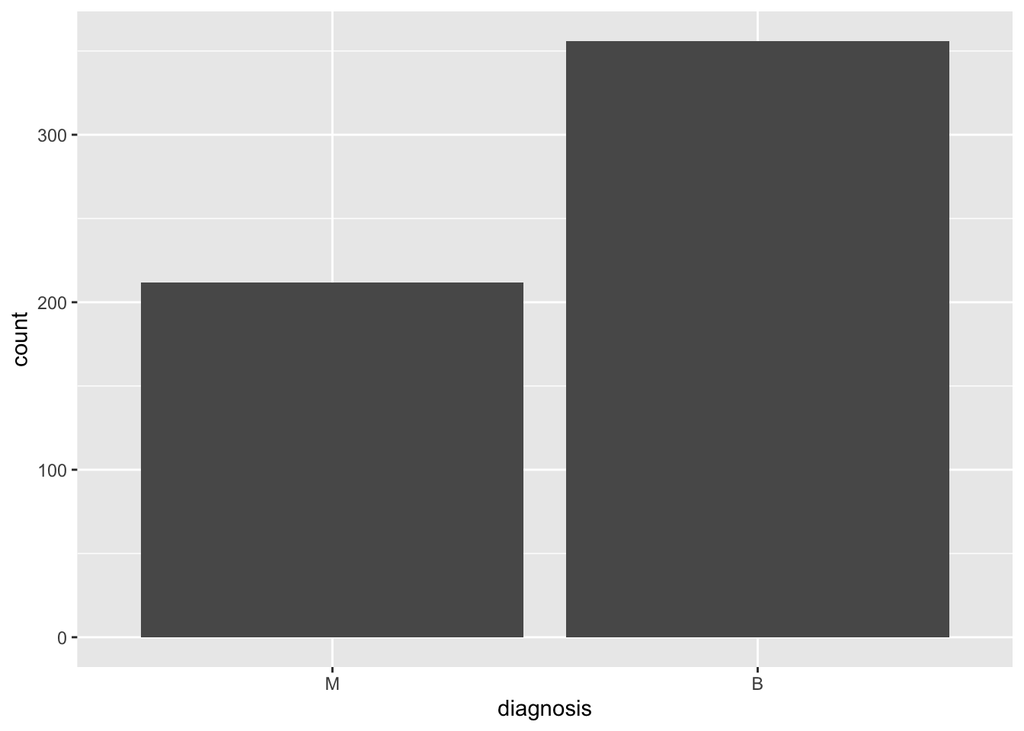

```r
ggplot(data, aes(x= diagnosis)) + geom_bar()
```

looking at distribution numerically:

```r
data %>%
select(diagnosis) %>%
  count(diagnosis)
```

```
## # A tibble: 2 × 2
##   diagnosis     n
##   <fct>     <int>
## 1 M           212
## 2 B           356
```

In our dataset there are more benign tumors than malignant tumors, around 1.5x more.

looking at more variables:

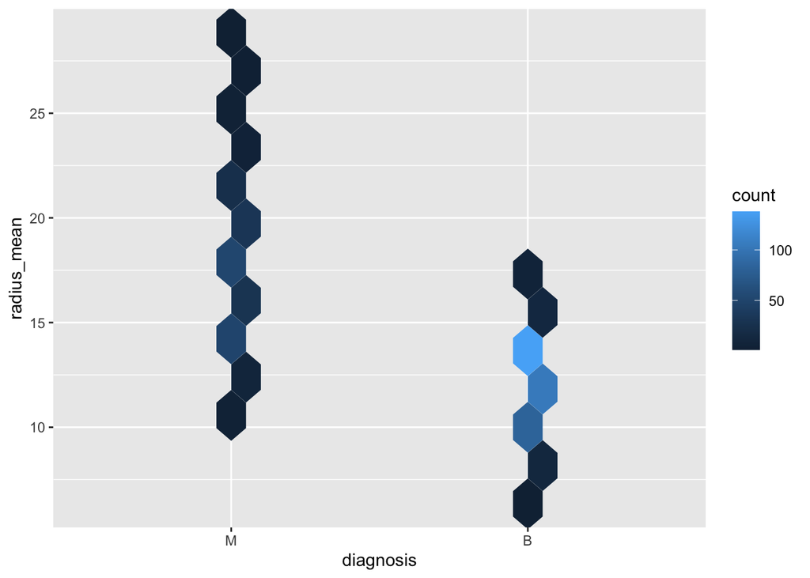

```r
ggplot(data, aes(diagnosis, radius_mean)) + geom_hex(bins=10)
```

Interestingly, there seems to be a bit of overlap between benign and malignant tumor when the radius of the tumor is 10 and 15 cm. I’d like to explore this more and see if I notice any patterns with the other variable.

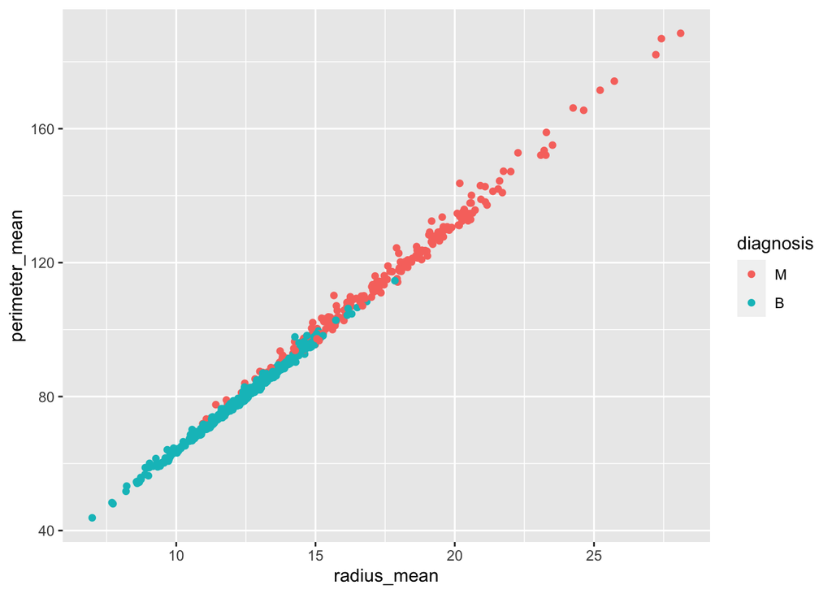

```r
ggplot(data, aes(radius_mean, perimeter_mean, colour= diagnosis)) + geom_jitter()
```

It looks like perimeter does strongly affect the outcome of the diagnosis. It seems that in the 10-15 cm radius interval, the perimeter does have a big impact. If the perimeter is under 70 cm, the tumor will be benign. If the perimeter is above 100 cm, there is a strong chance the tumor will be malignant. Overall, though, the overlap still seems to be minor.

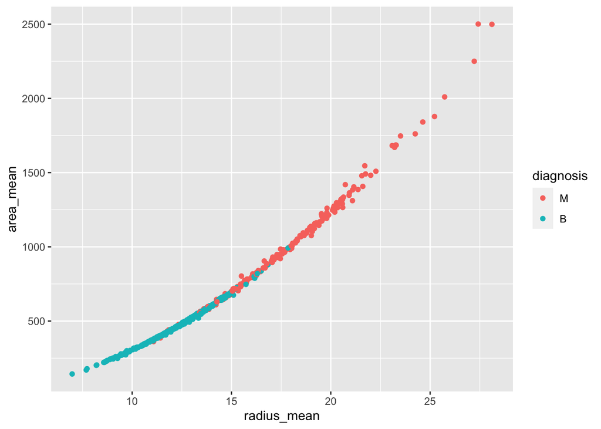

```r
ggplot(data, aes(radius_mean, area_mean, color=diagnosis)) + geom_jitter()
```

Interestingly, this looks like exponential growth of area_mean with linear increase with regards to radius mean. Since it’s not the outcome variable, I won’t log it.

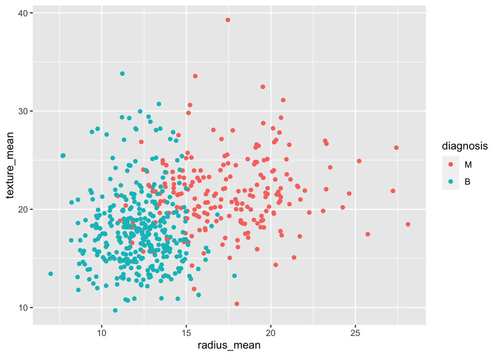

```r
ggplot(data, aes(radius_mean, texture_mean, colour= diagnosis)) + geom_jitter()
```

At this point, I’m noticing all my graphs look very different, meaning (I’m guessing) the variables all have pretty different impacts on my outcome variable: diagnosis. I’m curious to see what effect this has on my models once I start the modeling process. *note: I used a different graph for diagnosis vs. radius mean because I thought it was much more confusing to look at compared to the graph I created with geom_hex*

Splitting the data:

```r
data_split <- data %>%
  initial_split(prop=.8, strata= diagnosis)
train <- data_split %>% training()
test <- data_split %>% testing()
```

I’m splitting it by diagnosis because diagnosis is my outcome variable, and in past labs we’ve always made the strata the outcome variable.

Resampling data with V-Fold Cross Validation:

```r
data_resamples <-
  train %>%
  vfold_cv(v=5, repeats = 3, strata = diagnosis)

keep_pred<- control_resamples(save_pred = TRUE, save_workflow = TRUE)
```

Recipe:

```r
train<- tibble(train)
recipe <- recipe(diagnosis ~ id + radius_mean +  texture_mean +  perimeter_mean + area_mean + smoothness_mean + compactness_mean + concavity_mean + concave_points_mean + symmetry_mean + fractal_dimension_mean, data=train) %>%
  step_dummy(all_nominal_predictors()) %>%
  step_normalize(all_predictors())
```

Checking the recipe:

```r
recipe %>%
 prep() %>%
 bake(new_data= train)
```

```
## # A tibble: 453 × 12
##        id radius_mean texture_mean perimeter_mean area_mean smoothness_mean
##     <dbl>       <dbl>        <dbl>          <dbl>     <dbl>           <dbl>
##  1 -0.172      -0.304       -0.800         -0.268    -0.392          0.772
##  2 -0.172      -1.33        -1.55          -1.32     -1.11           0.412
##  3 -0.241      -0.318       -0.178         -0.394    -0.381         -0.476
##  4  0.517      -1.71        -0.541         -1.68     -1.32          -0.746
##  5 -0.241      -0.600       -1.05          -0.585    -0.597          0.461
##  6 -0.241      -0.683        0.551         -0.723    -0.659         -0.720
##  7 -0.241      -0.143       -0.656         -0.203    -0.241         -1.39
##  8 -0.241      -0.632       -0.220         -0.682    -0.631         -0.986
##  9  0.517      -0.752       -0.103         -0.781    -0.714         -0.0940
## 10 -0.241      -1.59        -1.70          -1.57     -1.25           0.0671
## # … with 443 more rows, and 6 more variables: compactness_mean <dbl>,
## #   concavity_mean <dbl>, concave_points_mean <dbl>, symmetry_mean <dbl>,
## #   fractal_dimension_mean <dbl>, diagnosis <fct>
```

## KNN MODEL

First, I’m going to try the k-nearest-neighbor model:

```r
kknn_model <- nearest_neighbor(mode = "classification",
                       neighbors = tune()) %>%
  set_engine("kknn")


# workflow
knn_wflow <-
  workflow() %>%
  add_recipe(recipe) %>%
  add_model(kknn_model)

#tuning params
kknn_params <- parameters(knn_wflow)
kknn_params %>%
  update(neighbors= neighbors(range= c(5,25)))
```

```
## Collection of 1 parameters for tuning
##
##  identifier      type    object
##   neighbors neighbors nparam[+]
```

```r
grid_info <- grid_regular(kknn_params, levels = 5)

#fit to resamples
knn_res <- knn_wflow %>%
  tune_grid(resamples= data_resamples,
            control= keep_pred,
            grid= grid_info
  )

save(knn_res, file= 'knn_res.rda')
```

Looking at the metrics:

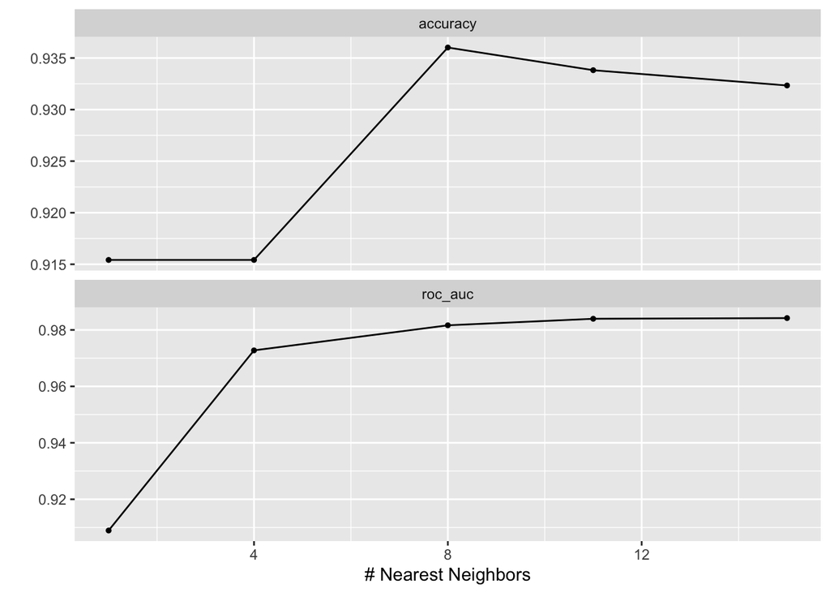

```r
load('knn_res.rda')
knn_res %>%
  autoplot()
```

```r
knn_res %>%
  collect_metrics() %>%
  filter() %>%
  arrange(mean)
```

```
## # A tibble: 10 × 7
##    neighbors .metric  .estimator  mean     n std_err .config
##        <int> <chr>    <chr>      <dbl> <int>   <dbl> <chr>
##  1         1 roc_auc  binary     0.909    15 0.00584 Preprocessor1_Model1
##  2         1 accuracy binary     0.915    15 0.00564 Preprocessor1_Model1
##  3         4 accuracy binary     0.915    15 0.00564 Preprocessor1_Model2
##  4        15 accuracy binary     0.932    15 0.00618 Preprocessor1_Model5
##  5        11 accuracy binary     0.934    15 0.00601 Preprocessor1_Model4
##  6         8 accuracy binary     0.936    15 0.00613 Preprocessor1_Model3
##  7         4 roc_auc  binary     0.973    15 0.00374 Preprocessor1_Model2
##  8         8 roc_auc  binary     0.982    15 0.00281 Preprocessor1_Model3
##  9        11 roc_auc  binary     0.984    15 0.00284 Preprocessor1_Model4
## 10        15 roc_auc  binary     0.984    15 0.00298 Preprocessor1_Model5
```

## LOGISTIC REGRESSION MODEL

Next, I’m going to try the logistic regression model:

```r
log_model <- logistic_reg() %>%
  set_engine("glm")


# workflow
log_wf <- workflow() %>%
  add_model(log_model) %>%
  add_recipe(recipe)

# this engine has no tuning parameters, as I see from it's documentation. This means I will have no tuning parameters section.

#fit to resamples
log_res <- log_wf %>%
  tune_grid(resamples= data_resamples,
            control= keep_pred,
            grid= grid_info
  )
save(log_res, file= 'log_res.rda')
```

```r
load('log_res.rda')
log_res %>%
  collect_metrics() %>%
  filter() %>%
  arrange(mean)
```

```
## # A tibble: 2 × 6
##   .metric  .estimator  mean     n std_err .config
##   <chr>    <chr>      <dbl> <int>   <dbl> <chr>
## 1 accuracy binary     0.929    15 0.00702 Preprocessor1_Model1
## 2 roc_auc  binary     0.982    15 0.00267 Preprocessor1_Model1
```

My accuracy and ROC AUC both look really good to me. Since I don’t have any tuning parameters, I’ll use this model with my testing data for my final fit.

```r
#finalmodelspec
final_wflow <-
  log_res %>%
  extract_workflow()

final_model_fit<-
  final_wflow %>%
  fit(train)
```

### Looking at Predictions & Metrics

```r
data_log_pred <- bind_cols(predict(final_model_fit, test %>% select(-diagnosis)), test %>% select(diagnosis))

data_log_prob_pred <- bind_cols(predict(final_model_fit, test %>% select(-diagnosis), type = "prob"), test %>% select(diagnosis))

#accuracy
accuracy(data_log_pred, diagnosis, .pred_class)
```

```
## # A tibble: 1 × 3
##   .metric  .estimator .estimate
##   <chr>    <chr>          <dbl>
## 1 accuracy binary         0.957
```

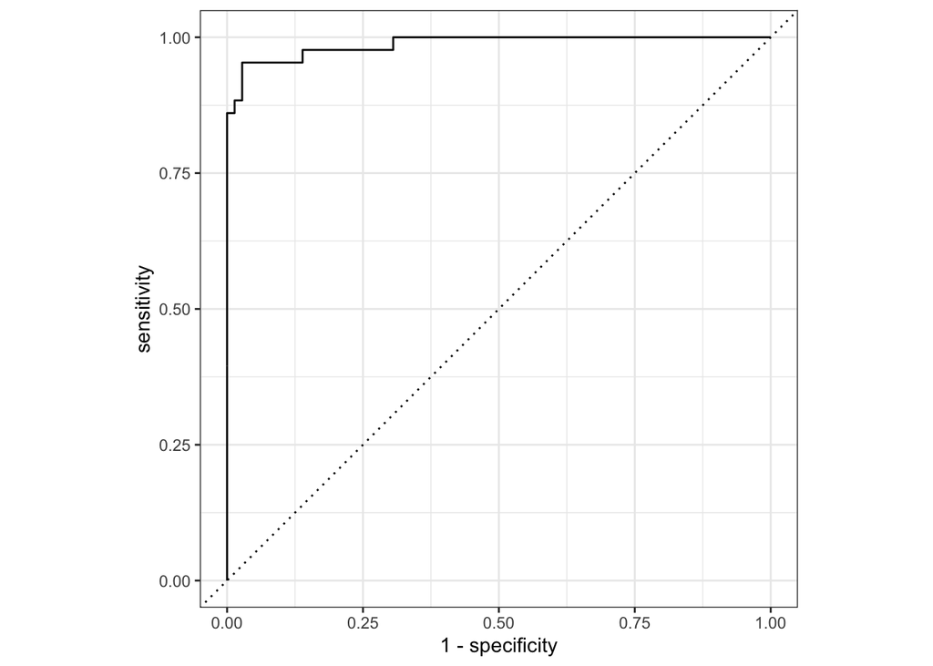

```r
#roc auc
roc_curve_log <- roc_curve(data_log_prob_pred, diagnosis, .pred_M)
autoplot(roc_curve_log)
```

```r
roc_auc(data_log_prob_pred, diagnosis, .pred_M)
```

```
## # A tibble: 1 × 3
##   .metric .estimator .estimate
##   <chr>   <chr>          <dbl>
## 1 roc_auc binary         0.987
```

creating model & workflow, then turning the parameters and fitting them to the resamples.

```r
boost_model <- boost_tree(mode = "classification",
                          mtry = tune(),
                        min_n = tune(),
                        learn_rate= tune()) %>%
                    set_engine("xgboost")

# workflow
boost_wflow <-
  workflow() %>%
  add_recipe(recipe) %>%
  add_model(boost_model)

#tuning params
boost_params <- parameters(boost_wflow)
boost_params <- boost_params %>%
  update(learn_rate= learn_rate(range=c(-20,-.1)),
         mtry=mtry(range=c(1,20)))
grid_info <- grid_regular(boost_params, levels = 5)

#fit to resamples
boost_res <- boost_wflow %>%
  tune_grid(resamples= data_resamples,
            control= keep_pred,
            grid= grid_info)
save(boost_res, file= 'boost_res.rda')
```

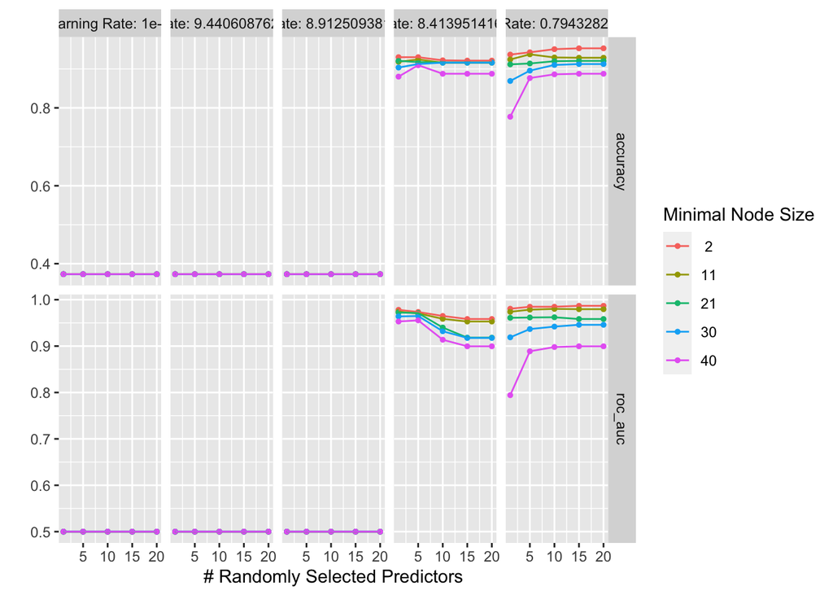

```r
load('boost_res.rda')
boost_res %>%
  autoplot()
```

```r
boost_res %>%
  collect_metrics() %>%
  filter() %>%
  arrange(mean)
```

```
## # A tibble: 250 × 9
##     mtry min_n learn_rate .metric  .estimator  mean     n  std_err .config
##    <int> <int>      <dbl> <chr>    <chr>      <dbl> <int>    <dbl> <chr>
##  1     1     2      1e-20 accuracy binary     0.373    15 0.000304 Preprocessor…
##  2     5     2      1e-20 accuracy binary     0.373    15 0.000304 Preprocessor…
##  3    10     2      1e-20 accuracy binary     0.373    15 0.000304 Preprocessor…
##  4    15     2      1e-20 accuracy binary     0.373    15 0.000304 Preprocessor…
##  5    20     2      1e-20 accuracy binary     0.373    15 0.000304 Preprocessor…
##  6     1    11      1e-20 accuracy binary     0.373    15 0.000304 Preprocessor…
##  7     5    11      1e-20 accuracy binary     0.373    15 0.000304 Preprocessor…
##  8    10    11      1e-20 accuracy binary     0.373    15 0.000304 Preprocessor…
##  9    15    11      1e-20 accuracy binary     0.373    15 0.000304 Preprocessor…
## 10    20    11      1e-20 accuracy binary     0.373    15 0.000304 Preprocessor…
## # … with 240 more rows
```

Since I have so many options for my predictors, the visualization of the metrics isn’t very helpful. I’m going to filter it down so only mean values of above .95 are shown.

```r
boost_res %>%
  collect_metrics() %>%
  filter(mean > .95)
```

```
## # A tibble: 34 × 9
##     mtry min_n learn_rate .metric .estimator  mean     n std_err .config
##    <int> <int>      <dbl> <chr>   <chr>      <dbl> <int>   <dbl> <chr>
##  1     1     2 0.00000841 roc_auc binary     0.978    15 0.00345 Preprocessor1_…
##  2     5     2 0.00000841 roc_auc binary     0.974    15 0.00430 Preprocessor1_…
##  3    10     2 0.00000841 roc_auc binary     0.965    15 0.00562 Preprocessor1_…
##  4    15     2 0.00000841 roc_auc binary     0.958    15 0.00711 Preprocessor1_…
##  5    20     2 0.00000841 roc_auc binary     0.958    15 0.00711 Preprocessor1_…
##  6     1    11 0.00000841 roc_auc binary     0.974    15 0.00376 Preprocessor1_…
##  7     5    11 0.00000841 roc_auc binary     0.971    15 0.00364 Preprocessor1_…
##  8    10    11 0.00000841 roc_auc binary     0.959    15 0.00649 Preprocessor1_…
##  9    15    11 0.00000841 roc_auc binary     0.953    15 0.00652 Preprocessor1_…
## 10    20    11 0.00000841 roc_auc binary     0.953    15 0.00652 Preprocessor1_…
## # … with 24 more rows
```

```r
select_best(boost_res)
```

```
## # A tibble: 1 × 4
##    mtry min_n learn_rate .config
##   <int> <int>      <dbl> <chr>
## 1    15     2      0.794 Preprocessor1_Model104
```

### Fitting Final Boosted Model

```r
boost_params <- tibble(mtry=10, min_n=2, learn_rate=0.7943282)

#finalmodelspec
final_wflow <-
  boost_res %>%
  extract_workflow()%>%
  finalize_workflow(parameters=boost_params)

final_model_fit<-
  final_wflow %>%
  fit(train)
```

```
## [22:51:00] WARNING: amalgamation/../src/learner.cc:1115: Starting in XGBoost 1.3.0, the default evaluation metric used with the objective 'binary:logistic' was changed from 'error' to 'logloss'. Explicitly set eval_metric if you'd like to restore the old behavior.
```

```r
data_boost_pred <- bind_cols(predict(final_model_fit, test %>% select(-diagnosis)), test %>% select(diagnosis))

data_boost_prob_pred <- bind_cols(predict(final_model_fit, test %>% select(-diagnosis), type = "prob"), test %>% select(diagnosis))

#accuracy
accuracy(data_boost_pred, diagnosis, .pred_class)
```

```
## # A tibble: 1 × 3
##   .metric  .estimator .estimate
##   <chr>    <chr>          <dbl>
## 1 accuracy binary         0.957
```

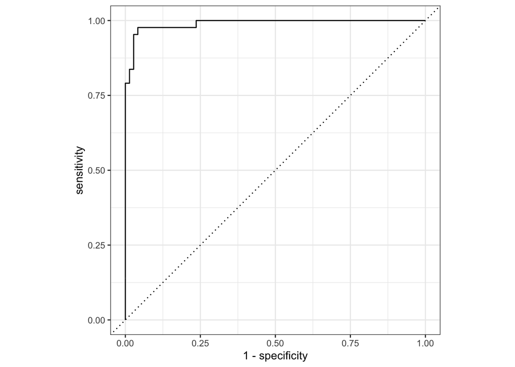

```r
#roc auc
roc_curve_boost <- roc_curve(data_boost_prob_pred, diagnosis, .pred_M)
autoplot(roc_curve_boost)
```

```r
roc_auc(data_boost_prob_pred, diagnosis, .pred_M)
```

```
## # A tibble: 1 × 3
##   .metric .estimator .estimate
##   <chr>   <chr>          <dbl>
## 1 roc_auc binary         0.990
```

## Random Forest

```r
rf_model <- rand_forest(mode = "classification",
                        min_n = tune(),
                        mtry = tune(),
                   trees= 2000) %>%
  set_engine("ranger")

rf_wflow <- workflow() %>%
  add_recipe(recipe) %>%
  add_model(rf_model)

rf_params <- parameters(rf_wflow)

rf_params <- rf_params %>%
  update(mtry=mtry(range=c(1,11))
  )
grid_info <- grid_regular(rf_params, levels=5)

rf_res <- rf_wflow %>%
  tune_grid(resamples= data_resamples,
            control= keep_pred,
            grid= grid_info)
```

```r
save(rf_res, file= 'rf_res.rda')
```

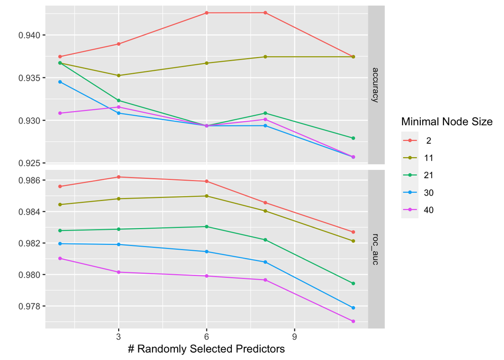

```r
load('rf_res.rda')
rf_res %>%
  autoplot()
```

```r
rf_res %>%
  collect_metrics() %>%
  filter() %>%
  arrange(mean)
```

```
## # A tibble: 50 × 8
##     mtry min_n .metric  .estimator  mean     n std_err .config
##    <int> <int> <chr>    <chr>      <dbl> <int>   <dbl> <chr>
##  1    11    30 accuracy binary     0.926    15 0.00781 Preprocessor1_Model20
##  2    11    40 accuracy binary     0.926    15 0.00795 Preprocessor1_Model25
##  3    11    21 accuracy binary     0.928    15 0.00785 Preprocessor1_Model15
##  4     6    21 accuracy binary     0.929    15 0.00699 Preprocessor1_Model13
##  5     6    30 accuracy binary     0.929    15 0.00739 Preprocessor1_Model18
##  6     6    40 accuracy binary     0.929    15 0.00739 Preprocessor1_Model23
##  7     8    30 accuracy binary     0.929    15 0.00697 Preprocessor1_Model19
##  8     8    40 accuracy binary     0.930    15 0.00688 Preprocessor1_Model24
##  9     8    21 accuracy binary     0.931    15 0.00711 Preprocessor1_Model14
## 10     3    30 accuracy binary     0.931    15 0.00703 Preprocessor1_Model17
## # … with 40 more rows
```

```r
load('rf_res.rda')
select_best(rf_res)
```

```
## # A tibble: 1 × 3
##    mtry min_n .config
##   <int> <int> <chr>
## 1     3     2 Preprocessor1_Model02
```

```r
#tuning params
select_best(rf_res)
```

```
## # A tibble: 1 × 3
##    mtry min_n .config
##   <int> <int> <chr>
## 1     3     2 Preprocessor1_Model02
```

```r
rf_params <- tibble(mtry=2, min_n=2)

#finalmodelspec
final_wflow <-
  rf_res %>%
  extract_workflow()%>%
  finalize_workflow(parameters=rf_params)

final_model_fit<-
  final_wflow %>%
  fit(train)
```

### Looking at Predictions & Metrics

```r
data_rf_pred <- bind_cols(predict(final_model_fit, test %>% select(-diagnosis)), test %>% select(diagnosis))

data_rf_prob_pred <- bind_cols(predict(final_model_fit, test %>% select(-diagnosis), type = "prob"), test %>% select(diagnosis))

#accuracy
accuracy(data_rf_pred, diagnosis, .pred_class)
```

```
## # A tibble: 1 × 3
##   .metric  .estimator .estimate
##   <chr>    <chr>          <dbl>
## 1 accuracy binary         0.930
```

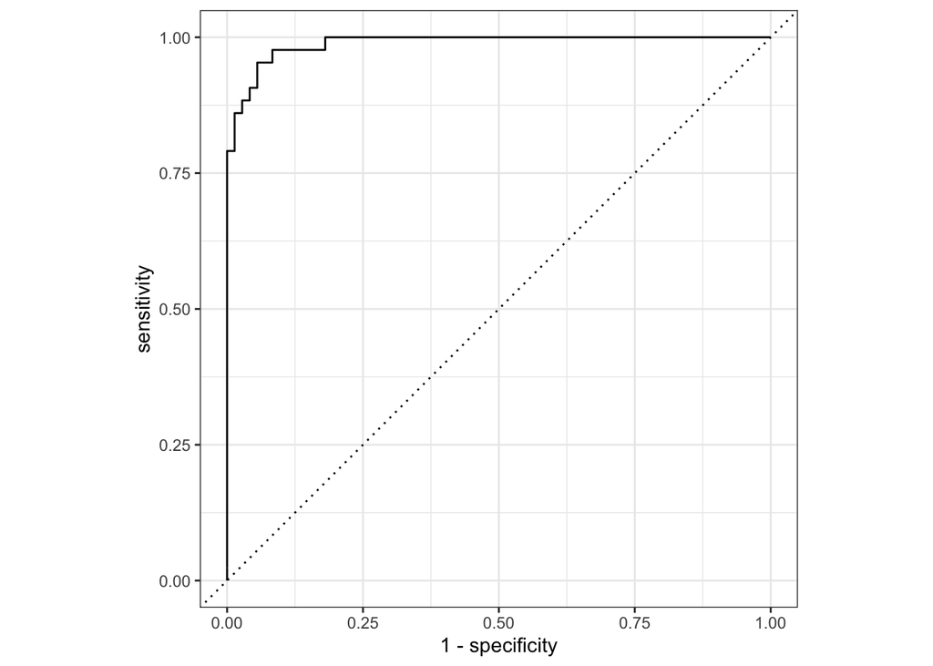

```r
#roc auc
roc_curve_rf <- roc_curve(data_rf_prob_pred, diagnosis, .pred_M)
autoplot(roc_curve_rf)
```

```r
roc_auc(data_rf_prob_pred, diagnosis, .pred_M)
```

```
## # A tibble: 1 × 3
##   .metric .estimator .estimate
##   <chr>   <chr>          <dbl>
## 1 roc_auc binary         0.989
```

## Final Model: Boosted Forests

Since my boosted forests was the most successful out of all my models (K-Nearest Neighbors, Logistic Regression and Random Forest) I am going to try tuning it even more to see if I can get the accuracy above 95.7%.

```r
final_model <- boost_tree(mode = "classification",
                          mtry = tune(),
                        min_n = 2,
                        learn_rate= tune()) %>%
                    set_engine("xgboost")

# workflow
final_wflow <-
  workflow() %>%
  add_recipe(recipe) %>%
  add_model(final_model)

#tuning params
final_params <- parameters(final_wflow)
final_params <- final_params %>%
  update(learn_rate= learn_rate(range=c(-1,-.05)),
         mtry=mtry(range=c(1,11)))
grid_info <- grid_regular(final_params, levels = 5)

#fit to resamples
final_res <- final_wflow %>%
  tune_grid(resamples= data_resamples,
            control= keep_pred,
            grid= grid_info)
```

```r
save(final_res, file='final_res.rda')
```

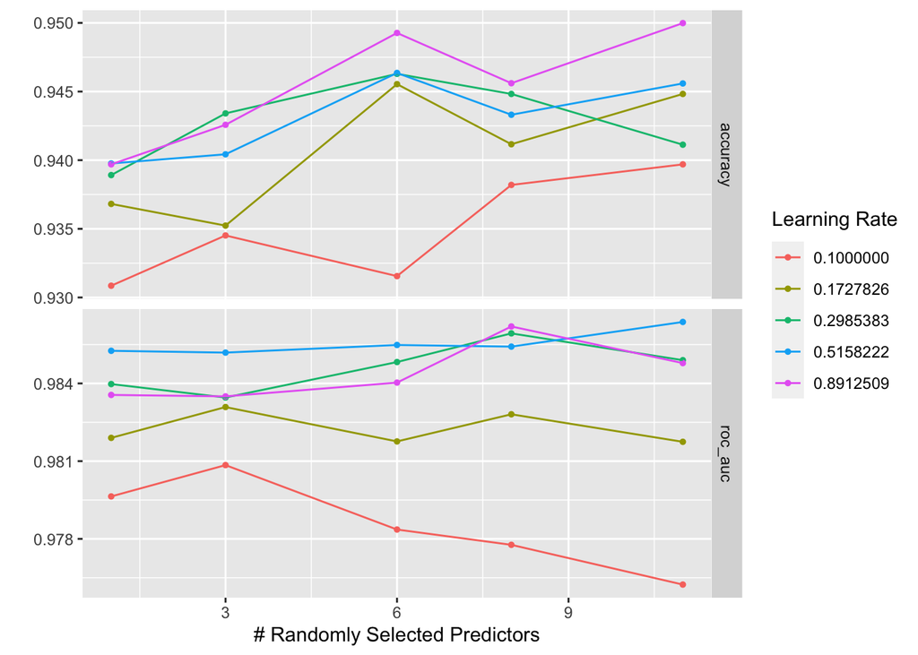

```r
load('final_res.rda')
final_res %>%
  autoplot()
```

```r
final_res %>%
  collect_metrics() %>%
  filter(mean > .95)
```

```
## # A tibble: 25 × 8
##     mtry learn_rate .metric .estimator  mean     n std_err .config
##    <int>      <dbl> <chr>   <chr>      <dbl> <int>   <dbl> <chr>
##  1     1      0.1   roc_auc binary     0.980    15 0.00338 Preprocessor1_Model01
##  2     3      0.1   roc_auc binary     0.981    15 0.00280 Preprocessor1_Model02
##  3     6      0.1   roc_auc binary     0.978    15 0.00314 Preprocessor1_Model03
##  4     8      0.1   roc_auc binary     0.978    15 0.00356 Preprocessor1_Model04
##  5    11      0.1   roc_auc binary     0.976    15 0.00342 Preprocessor1_Model05
##  6     1      0.173 roc_auc binary     0.982    15 0.00333 Preprocessor1_Model06
##  7     3      0.173 roc_auc binary     0.983    15 0.00288 Preprocessor1_Model07
##  8     6      0.173 roc_auc binary     0.982    15 0.00341 Preprocessor1_Model08
##  9     8      0.173 roc_auc binary     0.983    15 0.00260 Preprocessor1_Model09
## 10    11      0.173 roc_auc binary     0.982    15 0.00256 Preprocessor1_Model10
## # … with 15 more rows
```

It looks like there isn’t any accuracy above .95, but maybe with the testing set it will prove to be greater.

```r
select_best(final_res)
```

```
## # A tibble: 1 × 3
##    mtry learn_rate .config
##   <int>      <dbl> <chr>
## 1    11      0.516 Preprocessor1_Model20
```

```r
final_params <- tibble(mtry=11, min_n=2, learn_rate= 0.5158222)

#finalmodelspec
final_wflow <-
  final_res %>%
  extract_workflow()%>%
  finalize_workflow(parameters=final_params)

final_model_fit<-
  final_wflow %>%
  fit(train)
```

```
## [22:56:32] WARNING: amalgamation/../src/learner.cc:1115: Starting in XGBoost 1.3.0, the default evaluation metric used with the objective 'binary:logistic' was changed from 'error' to 'logloss'. Explicitly set eval_metric if you'd like to restore the old behavior.
```

```r
data_final_pred <- bind_cols(predict(final_model_fit, test %>% select(-diagnosis)), test %>% select(diagnosis))

data_final_prob_pred <- bind_cols(predict(final_model_fit, test %>% select(-diagnosis), type = "prob"), test %>% select(diagnosis))

#accuracy
accuracy(data_final_pred, diagnosis, .pred_class)
```

```
## # A tibble: 1 × 3
##   .metric  .estimator .estimate
##   <chr>    <chr>          <dbl>
## 1 accuracy binary         0.948
```

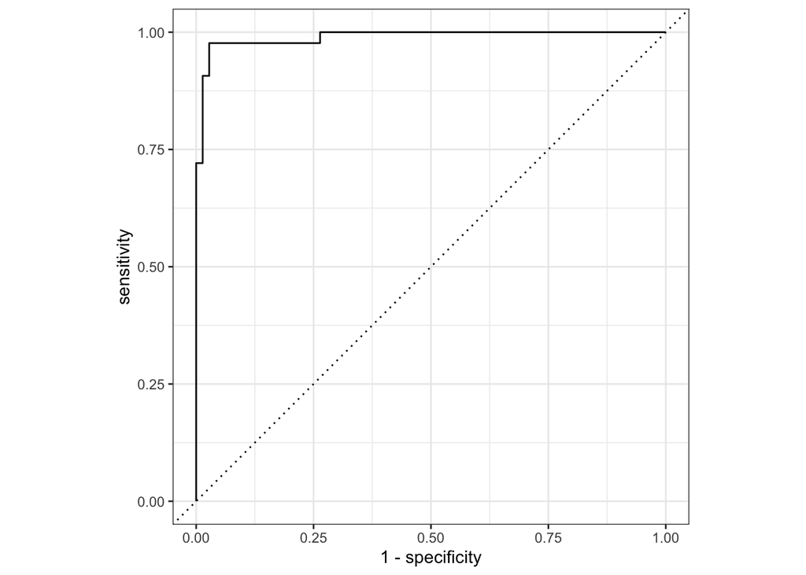

```r
#roc auc
roc_curve_final <- roc_curve(data_final_prob_pred, diagnosis, .pred_M)
autoplot(roc_curve_final)
```

```r
roc_auc(data_final_prob_pred, diagnosis, .pred_M)
```

```
## # A tibble: 1 × 3
##   .metric .estimator .estimate
##   <chr>   <chr>          <dbl>
## 1 roc_auc binary         0.989
```

I know from testing different values for mtry that the accuracy value stays the same for mtry=11 and values above 11. This makes sense because the number of predictors I have in my model is 11.